# Course Project - Practical Machine Learning

Victoria Dotta

28/2/2017

# Background

Using devices such as Jawbone Up, Nike FuelBand, and Fitbit it is now possible to collect a large amount of data about personal activity relatively inexpensively. These type of devices are part of the quantified self movement – a group of enthusiasts who take measurements about themselves regularly to improve their health, to find patterns in their behavior, or because they are tech geeks. One thing that people regularly do is quantify how much of a particular activity they do, but they rarely quantify how well they do it.

In this project, your goal will be to use data from accelerometers on the belt, forearm, arm, and dumbell of 6 participants. They were asked to perform barbell lifts correctly and incorrectly in 5 different ways. More information is available from the website here: http://groupware.les.inf.puc-rio.br/har (see the section on the Weight Lifting Exercise Dataset).

# Objective

The goal of your project is to predict the manner in which they did the exercise. This is the “classe” variable in the training set. You may use any of the other variables to predict with. You should create a report describing how you built your model, how you used cross validation, what you think the expected out of sample error is, and why you made the choices you did. You will also use your prediction model to predict 20 different test cases.

# Data

The training data for this project are available here:

https://d396qusza40orc.cloudfront.net/predmachlearn/pml-training.csv

The test data are available here:

https://d396qusza40orc.cloudfront.net/predmachlearn/pml-testing.csv

The data for this project come from this source: http://groupware.les.inf.puc-rio.br/har.

# Getting and cleaning the data

## Getting the data

```r
setwd("~/Documents/Coursera/Data Science Specialization/Practical Machine Learning/Archivos")

trainURL <- "https://d396qusza40orc.cloudfront.net/predmachlearn/pml-training.csv"
testURL <- "https://d396qusza40orc.cloudfront.net/predmachlearn/pml-testing.csv"

download.file(trainURL, destfile = "./train.csv", method = "curl")
download.file(testURL, destfile = "./test.csv", method = "curl")

train <- read.csv("train.csv", na.strings = c("NA", "#DIV/0!", ""))
test <- read.csv("test.csv", na.strings = c("NA", "DIV/0!", ""))
```

## Cross validation

I am goingo to create a “test” dataset in the training phase.

```r
install.packages("caret", repos = "http://cran.us.r-project.org" , dependencies = TRUE)
library(caret)
set.seed(123)

inTrain <- createDataPartition(y = train$classe, p = 0.6, list = FALSE)
training <- train[inTrain,]
testing <- train[-inTrain,]
```

```r
dim(training)
```

```
## [1] 11776   160
```

```r
dim(testing)
```

```
## [1] 7846  160
```

## Cleaning the data

```r
# nearly zero variance variables

nzv <- nearZeroVar(training)

training <- training[,-nzv]
testing <- testing[,-nzv]
test <- test[, -nzv]

# mostly NA variables

na <- sapply(training, function(x) mean(is.na(x))) > 0.75

training <- training[, na == FALSE]
testing <- testing[, na == FALSE]
test <- test[, na == FALSE]
```

Now, I am going to remove the first two columns, which have no interest for prediction.

```r
training <- training[,-c(1,2)]
testing <- testing[,-c(1,2)]
test <- test[,-c(1,2)]
```

# Decision tree model

### The model:

```r
install.packages("rpart", repos = "http://cran.us.r-project.org")
```

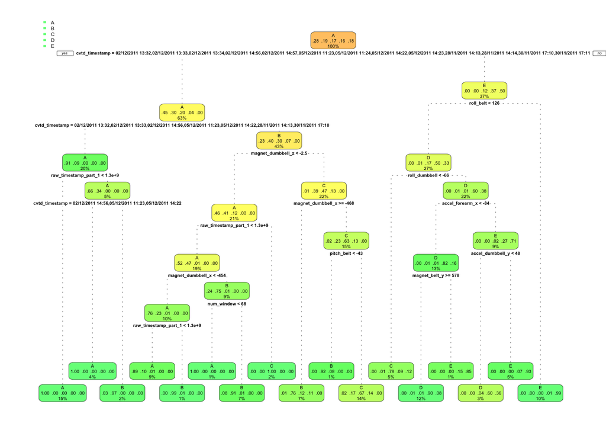

```r
library(rpart)
install.packages("rpart.plot", repos = "http://cran.us.r-project.org")
library(rpart.plot)
install.packages("rattle", repos = "http://cran.us.r-project.org")
library(rattle)
set.seed(580)

DTmodel <- rpart(classe ~ ., method = "class", data = training)
rpart.plot(DTmodel, branch.lty=3, box.palette="RdYlGn" )
```

### Predictions:

```r
predictionsDT <- predict(DTmodel, testing, type = "class")
confusionMatrix(predictionsDT, testing$classe)
```

```
## Confusion Matrix and Statistics
##
##           Reference
## Prediction    A    B    C    D    E
##          A 2144   63    9    2    0
##          B   65 1291  102   65    0
##          C   23  157 1233  204   61
##          D    0    7   24  956  189
##          E    0    0    0   59 1192
##
## Overall Statistics
##
##                Accuracy : 0.8687
##                  95% CI : (0.861, 0.8761)
##     No Information Rate : 0.2845
##     P-Value [Acc > NIR] : < 2.2e-16
##
##                   Kappa : 0.834
##  Mcnemar's Test P-Value : NA
##
## Statistics by Class:
##
##                      Class: A Class: B Class: C Class: D Class: E
## Sensitivity            0.9606   0.8505   0.9013   0.7434   0.8266
## Specificity            0.9868   0.9633   0.9313   0.9665   0.9908
## Pos Pred Value         0.9666   0.8477   0.7348   0.8129   0.9528
## Neg Pred Value         0.9844   0.9641   0.9781   0.9505   0.9621
## Prevalence             0.2845   0.1935   0.1744   0.1639   0.1838
## Detection Rate         0.2733   0.1645   0.1572   0.1218   0.1519
## Detection Prevalence   0.2827   0.1941   0.2139   0.1499   0.1594
## Balanced Accuracy      0.9737   0.9069   0.9163   0.8549   0.9087
```

# Random Forest Model

### The model:

```r
install.packages("randomForest", repos = "http://cran.us.r-project.org" )
library(randomForest)
RFmodel <- randomForest(classe ~., data = training)
```

### Predictions:

```r
predictionsRF <- predict(RFmodel, testing, type = "class")
confusionMatrix(predictionsRF, testing$classe)
```

```
## Confusion Matrix and Statistics
##
##           Reference
## Prediction    A    B    C    D    E
##          A 2231    0    0    0    0
##          B    1 1518    2    0    0
##          C    0    0 1361    0    0
##          D    0    0    5 1286    1
##          E    0    0    0    0 1441
##
## Overall Statistics
##
##                Accuracy : 0.9989
##                  95% CI : (0.9978, 0.9995)
##     No Information Rate : 0.2845
##     P-Value [Acc > NIR] : < 2.2e-16
##
##                   Kappa : 0.9985
##  Mcnemar's Test P-Value : NA
##
## Statistics by Class:
##
##                      Class: A Class: B Class: C Class: D Class: E
## Sensitivity            0.9996   1.0000   0.9949   1.0000   0.9993
## Specificity            1.0000   0.9995   1.0000   0.9991   1.0000
## Pos Pred Value         1.0000   0.9980   1.0000   0.9954   1.0000
## Neg Pred Value         0.9998   1.0000   0.9989   1.0000   0.9998
## Prevalence             0.2845   0.1935   0.1744   0.1639   0.1838
## Detection Rate         0.2843   0.1935   0.1735   0.1639   0.1837
## Detection Prevalence   0.2843   0.1939   0.1735   0.1647   0.1837
## Balanced Accuracy      0.9998   0.9998   0.9974   0.9995   0.9997
```

## Conclusion

The Random Forest Model have better results than the Decision Tree Model.

# Apply the model to the test set

```r
m <- head(training,1)
m <- m[, -length(colnames(m))]
test1 <- test[, -length(colnames(test))]
test2 <- rbind(m, test1)
test2 <- test2[-1,]
prediction <- predict(RFmodel, test2, type = "class")
prediction
```

[output not shown]